# Desicion tree assignment

Kolumbet Anton

17 05 2022

This assignment is based on materials from [mlcourse.ai] (https://mlcourse.ai)

## Building a decision tree for predicting heart diseases

Let’s read the data on heart diseases. The dataset can be downloaded from the course repo from [here](https://www.dropbox.com/s/kr1d9vsnax5wxfo/mlbootcamp5_train.csv?dl=0).

**Problem**

Predict presence or absence of cardiovascular disease (CVD) using the patient examination results.

**Data description**

There are 3 types of input features:

- *Objective*: factual information;
- *Examination*: results of medical examination;
- *Subjective*: information given by the patient.

| Feature | Variable Type | Variable | Value Type |
| --- | --- | --- | --- |
| Age | Objective Feature | age | int (days) |
| Height | Objective Feature | height | int (cm) |
| Weight | Objective Feature | weight | float (kg) |
| Gender | Objective Feature | gender | categorical code |
| Systolic blood pressure | Examination Feature | ap_hi | int |
| Diastolic blood pressure | Examination Feature | ap_lo | int |
| Cholesterol | Examination Feature | cholesterol | 1: normal, 2: above normal, 3: well above normal |
| Glucose | Examination Feature | gluc | 1: normal, 2: above normal, 3: well above normal |
| Smoking | Subjective Feature | smoke | binary |
| Alcohol intake | Subjective Feature | alco | binary |
| Physical activity | Subjective Feature | active | binary |
| Presence or absence of cardiovascular disease | Target Variable | cardio | binary |

All of the dataset values were collected at the moment of medical examination.

## Task

Read the data

```r
mlbootcamp <- read.csv("mlbootcamp5_train.csv", sep=";")
```

Transform the features: - create “age in years” (`age_years`)dividing age by 365.25 and taking floor ($\lfloor{x}\rfloor$ is the largest integer that is less than or equal to $x$) - remove “age” feature - transfrom `cholesterol` and `gluc` to factor

```r
mlbootcamp$age_years <- floor(mlbootcamp$age/365.25)
mlbootcamp <- subset(mlbootcamp, select=-c(age, id))
mlbootcamp$cholesterol <- as.factor(mlbootcamp$cholesterol)
mlbootcamp$gluc <- as.factor(mlbootcamp$gluc)
mlbootcamp$cardio <- as.factor(mlbootcamp$cardio)

is.factor(mlbootcamp$cholesterol)
```

```
## [1] TRUE
```

```r
is.factor(mlbootcamp$gluc)
```

```
## [1] TRUE
```

Split data into train and test parts in the proportion of 7/3. The target feature is `cardio`

```r
#install.packages('caret')
library(caret)

set.seed(2344)
trainIndex <- createDataPartition(mlbootcamp$cardio, p = 0.7, list = FALSE, times = 1)
train <- mlbootcamp[trainIndex, ]
test  <- mlbootcamp[-trainIndex, ]

head(train, 3)
```

```
##   gender height weight ap_hi ap_lo cholesterol gluc smoke alco active cardio
## 1      2    168     62   110    80           1    1     0    0      1      0
## 2      1    156     85   140    90           3    1     0    0      1      1
## 3      1    165     64   130    70           3    1     0    0      0      1
##   age_years
## 1        50
## 2        55
## 3        51
```

```r
head(test, 3)
```

```
##    gender height weight ap_hi ap_lo cholesterol gluc smoke alco active cardio
## 5       1    156     56   100    60           1    1     0    0      0      0
## 15      2    181     95   130    90           1    1     1    1      1      0
## 28      1    159     78   120    80           1    1     0    0      1      0
##    age_years
## 5         47
## 15        39
## 28        49
```

Train a decision tree on the dataset `training` with **max depth equal to 3**. For setting this parameter use function `rpart::rpart.control`. Use default cross calidation parameters.

```r
#install.packages('rpart')
#install.packages('e1071', dependencies=TRUE)
library(rpart)
library(caret)
train1 <- train(cardio ~ ., data = train, method = "rpart", control = rpart.control(maxdepth = 3))

train1
```

```
## CART
##
## 49001 samples
##    11 predictor
##     2 classes: '0', '1'
##
## No pre-processing
## Resampling: Bootstrapped (25 reps)
## Summary of sample sizes: 49001, 49001, 49001, 49001, 49001, 49001, ...
## Resampling results across tuning parameters:
##
##   cp          Accuracy   Kappa
##   0.00481908  0.7252455  0.4506173
##   0.00971984  0.7199382  0.4400255
##   0.42914318  0.5748416  0.1536304
##
## Accuracy was used to select the optimal model using the largest value.
## The final value used for the model was cp = 0.00481908.
```

Plot final tree with `rattle` library

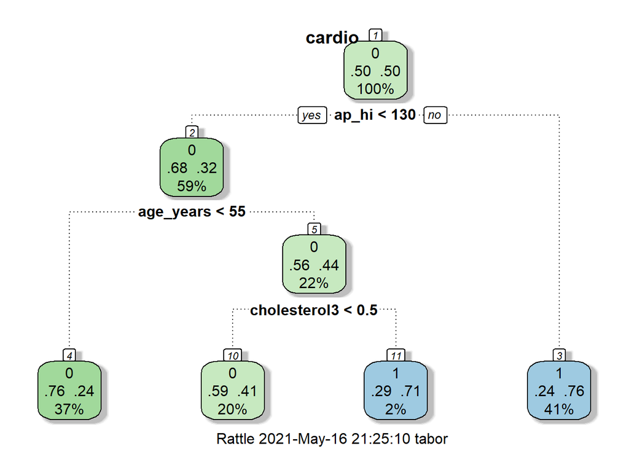

```r
#install.packages('rattle')
library(rattle)
plot1 <- fancyRpartPlot(train1$finalModel, main="cardio")
```

```r
plot1
```

What is the accuracy of prediction on test data?

```r
prediction1 <- predict(train1, test)
accuracy <- sum(prediction1 == test$cardio) / nrow(test)

accuracy
```

```
## [1] 0.7209867
```

Now set cross validation parameters: `method = "cv"`, `number = 5`. Tree parameters set to default.

```r
controlOfATrain <- trainControl(method = "cv", number = 5)
train2 <- train(cardio ~ ., data = train, method = "rpart", trControl = controlOfATrain)

train2
```

```
## CART
##
## 49001 samples
##    11 predictor
##     2 classes: '0', '1'
##
## No pre-processing
## Resampling: Cross-Validated (5 fold)
## Summary of sample sizes: 39200, 39201, 39201, 39201, 39201
## Resampling results across tuning parameters:
##
##   cp          Accuracy   Kappa
##   0.00481908  0.7263934  0.4527710
##   0.00971984  0.7182100  0.4363666
##   0.42914318  0.6275365  0.2547924
##
## Accuracy was used to select the optimal model using the largest value.
## The final value used for the model was cp = 0.00481908.
```

Plot final tree with `rattle` library

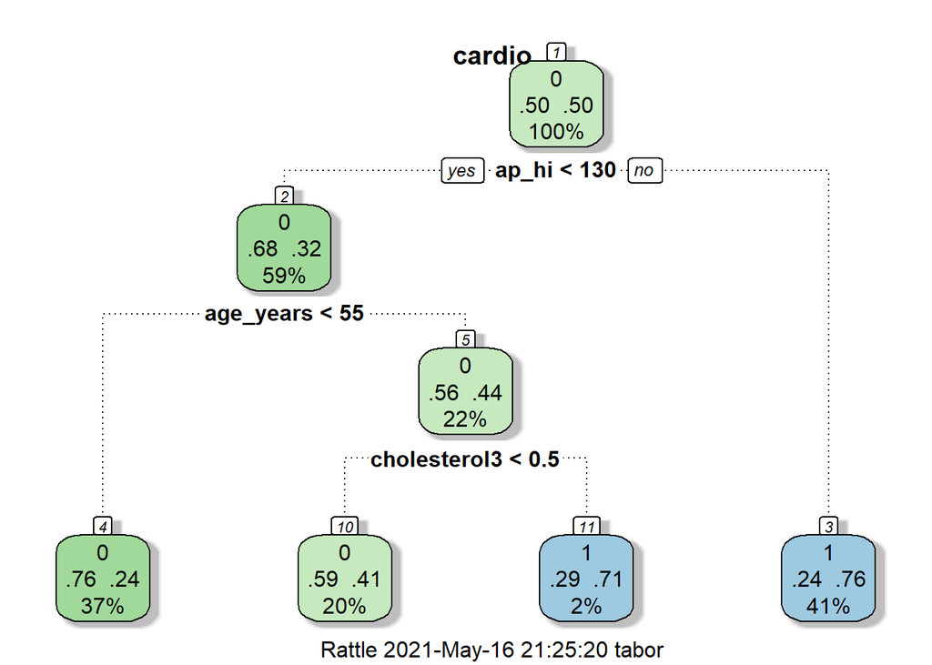

```r
library(rattle)
plot2 <- fancyRpartPlot(train2$finalModel, main="cardio")
```

```r
plot2
```

What is the accuracy of prediction on test data?

```r
prediction2 <- predict(train2, test)
accuracy2 <- sum(prediction2 == test$cardio) / nrow(test)

accuracy2
```

```
## [1] 0.7209867
```

Does the accuracy became better or not?

**No, It remained the same**